# Part I - Prosper Loan Dataset

### Talk about some of the relationships you observed in this part of the investigation. How did the feature(s) of interest vary with other features in the dataset?

> Amongst other observations, some include:
> 1. I can observe a negative correlation between some values like BorrowAPR and ProsperScore. Also a strong positive correlation between loanoroginalamount and monthlyloanpayment
> 2. There is a negavive correlation between BorrowerAPR and LoanOriginalAmount
> 3. From the boxplot, I saw that firstly,there are lots of outliers in the data. Second, we can observe that the loan amount increases with the loan term.

### Did you observe any interesting relationships between the other features (not the main feature(s) of interest)?

> When comparing StatedMonthlyIncome vs MonthlyLoanPayment I noticed there is a "somewhat positive correlation between the two variables", however, from the graph we can counf the extra 2 points at the end as outliers. If we do this then we will have to revisit our conclusion on the "positive correlation" between these 2 variables

## Multivariate Exploration

> Create plots of three or more variables to investigate your data even further. Make sure that your investigations are justified, and follow from your work in the previous sections.
1. Lets look at the relationship between BorrowereAPR and loan amount with a 3rd variables as the term

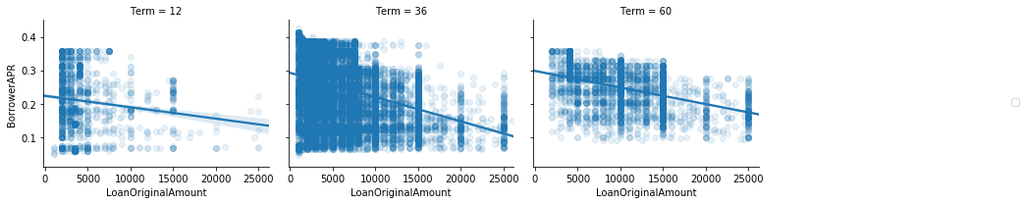

```python
g=sb.FacetGrid(data=loan_df, aspect=1.2, col='Term', col_wrap=4)
g.map(sb.regplot, 'LoanOriginalAmount', 'BorrowerAPR', x_jitter=0.03, scatter_kws={'alpha':0.1});
g.add_legend();
```

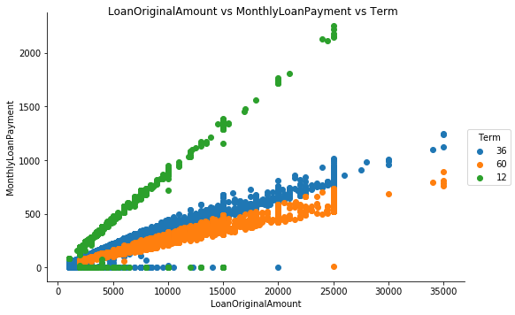

```python
g = sb.FacetGrid(data = loan_df, hue = 'Term',hue_order = [36, 60, 12], size = 5, aspect = 1.5)
g.map(plt.scatter, 'LoanOriginalAmount', 'MonthlyLoanPayment')
g.add_legend()
plt.suptitle("LoanOriginalAmount vs MonthlyLoanPayment vs Term");
```

> Observation: FRom above, we can see that oan term has an effect on the monthly payment. So loans for a shorter period of time have higher monthlyloanpayment.

### Were there any interesting or surprising interactions between features?

> The fact that loans within a shorter period of time had to be paid quicker so the monthly payment was higher.